# Associations between Species Characteristics

## Palmer’s Penguins

```r
data("penguins") #loads penguin data sets
pengs <- penguins_raw |>
  janitor::clean_names() |>
  #on the left are the new names we are giving the penguin species. On the right are the orinal names in the dataset
  mutate(species = fct_recode(species,
             Adelie = "Adelie Penguin (Pygoscelis adeliae)",
             Gentoo = "Gentoo penguin (Pygoscelis papua)",
             Chinstrap = "Chinstrap penguin (Pygoscelis antarctica)"))

#see all the variable names
names(pengs)
```

```
 [1] "study_name"        "sample_number"     "species"
 [4] "region"            "island"            "stage"
 [7] "individual_id"     "clutch_completion" "date_egg"
[10] "culmen_length_mm"  "culmen_depth_mm"   "flipper_length_mm"
[13] "body_mass_g"       "sex"               "delta_15_n_o_oo"
[16] "delta_13_c_o_oo"   "comments"
```

## Scatterplots

First, we might want to built just a simple scatterplot to determine if there is an association between culmen length (bill length) and culmen depth (bill depth).

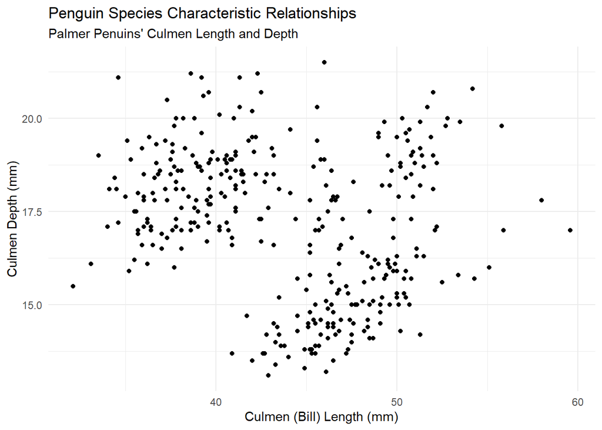

```r
ggplot(data = pengs,
       aes(x = culmen_length_mm, y = culmen_depth_mm)) +
  geom_point(size = 1.5) +
  labs(x = "Culmen (Bill) Length (mm)",
       y = "Culmen Depth (mm)",
       title = "Penguin Species Characteristic Relationships",
       subtitle = "Palmer Penuins' Culmen Length and Depth") +
  theme_minimal()
```

Do you notice anything interesting?

There appears to be some specific “groups” of points - perhaps this is due to species variation.

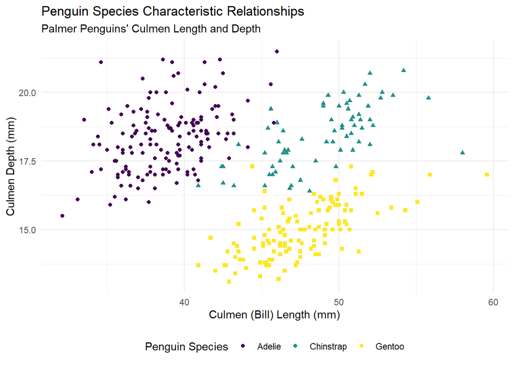

```r
ggplot(data = pengs,
       aes(x = culmen_length_mm, y = culmen_depth_mm)) +
  geom_point(aes(color = species, shape = species), size = 1.5) + #could be added in ggplot() line as well
  labs(x = "Culmen (Bill) Length (mm)",
       y = "Culmen Depth (mm)",
       title = "Penguin Species Characteristic Relationships",
       subtitle = "Palmer Penguins' Culmen Length and Depth") +
  theme_minimal() +
  scale_color_viridis_d(name = "Penguin Species") +
  guides(shape = "none") +
  theme(legend.position = "bottom")
```

Remember back to our first exploration of this data? There was also variation due to sex - we can add the shape parameter for sex. Notice that there is an NA for some of the sex, we can drop that data if we want.

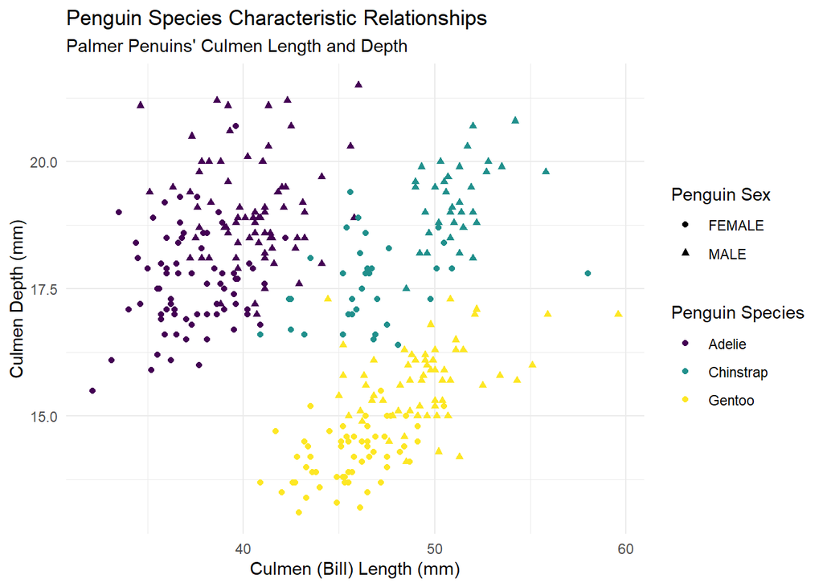

```r
#an example of saving a plot as an R object...
peng_plot <- pengs |>
  drop_na(sex) |>
  ggplot(aes(x = culmen_length_mm, y = culmen_depth_mm)) +
  geom_point(aes(color = species, shape = sex), size = 1.5) + #could be added in ggplot() line as well
  labs(x = "Culmen (Bill) Length (mm)",
       y = "Culmen Depth (mm)",
       title = "Penguin Species Characteristic Relationships",
       subtitle = "Palmer Penuins' Culmen Length and Depth",
       color = "Penguin Species",
       shape = "Penguin Sex") +
  theme_minimal() +
  scale_color_viridis_d()

#and then printing it!
peng_plot
```

This is a good opportunity to try some basic annotations! Let’s try text first.

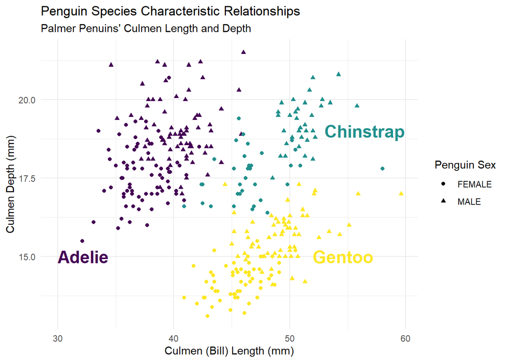

```r
#start with the plot from the last code chunk and add on to it

peng_plot +
  #add a text annotation! specify where it should start and what it should say
  #by default these center justify (center of word is at coordinate) but I want to left justify
  annotate(geom = "text", x=52, y=15, label = "Gentoo", color = "#FDE725FF", hjust="left", fontface="bold", size = 6) +
  annotate(geom = "text", x=30, y=15, label = "Adelie", color = "#440154FF", hjust="left", fontface="bold", size = 6) +
  annotate(geom = "text", x=53, y=19, label = "Chinstrap", color = "#21908CFF", hjust="left", fontface="bold", size = 6) +
  #since I added the annotations, I do not need the legend for color
  guides(color = "none")
```

```r
#this is how I found the color codes I wanted to use
viridis::viridis(3)
```

```
[1] "#440154FF" "#21908CFF" "#FDE725FF"
```

```r
# "#440154FF" "#21908CFF" "#FDE725FF"
```

The previous figure might be getting to crowded, so let’s consider splitting it by facets. Now I might consider coloring by sex and not species since the species are split into separate figures.

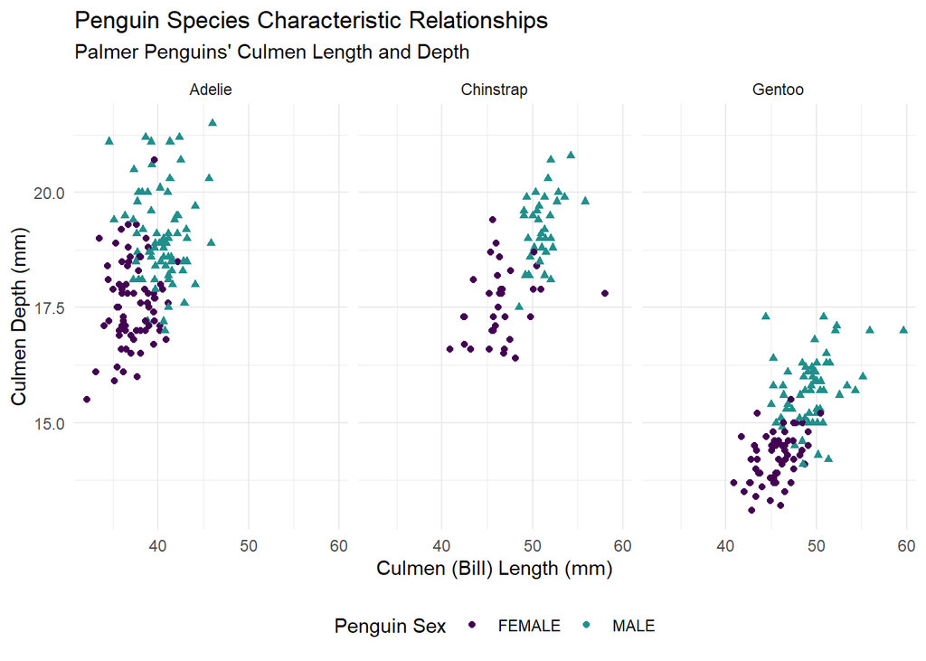

```r
pengs |>
  drop_na(sex) |>
  ggplot(aes(x = culmen_length_mm, y = culmen_depth_mm)) +
  geom_point(aes(color = sex, shape = sex), size = 1.5) + #could be added in ggplot() line as well
  labs(x = "Culmen (Bill) Length (mm)",
       y = "Culmen Depth (mm)",
       title = "Penguin Species Characteristic Relationships",
       subtitle = "Palmer Penguins' Culmen Length and Depth",
       color = "Penguin Sex") +
  theme_minimal() +
  scale_color_viridis_d(begin = 0, end = 0.5) +
  facet_wrap(~species) +
  guides(shape = "none") +
  theme(legend.position = "bottom")
```

Perhaps we want to demonstrate a more clear linear relationship between the two variables - we can add on another geometry

```r
#remember, need ggtext package for this code to work

#note we have missing data on the sex variable. We will filter out the missing cases so we don't get regression lines for the "missing" sex category
unique(pengs$sex)
```

```
[1] "MALE"   "FEMALE" NA
```

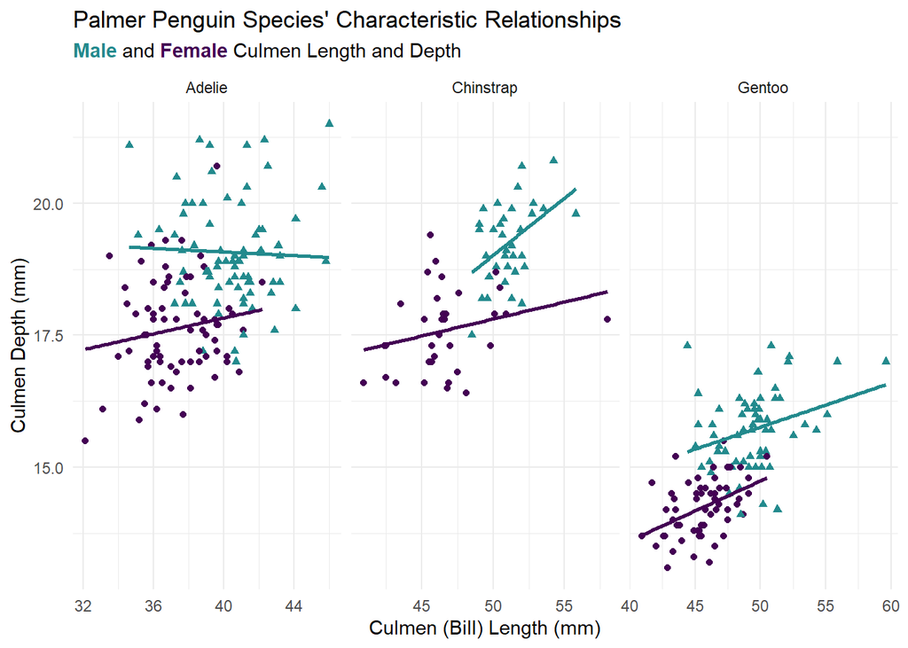

```r
pengs |>
  drop_na(sex) |>
  ggplot(aes(x = culmen_length_mm, y = culmen_depth_mm)) +
  geom_point(aes(color = sex, shape = sex), size = 1.5) +
  labs(x = "Culmen (Bill) Length (mm)",
       y = "Culmen Depth (mm)",
       title = "Palmer Penguin Species' Characteristic Relationships",
       #adding colors to Male and Female words in subtitle via ggtext package, so we don't need a legend
       subtitle = "<span style='color:#238A8DFF'>**Male**</span> and
    <span style='color:#440154FF'>**Female**</span> Culmen Length and Depth",
       color = "Penguin Sex") +
  theme_minimal() +
  scale_color_manual(breaks = c("MALE", "FEMALE"),
                     values = c("#238A8DFF", "#440154FF"),
                     labels = c("Male", "Female")) +
  #free_x allows each Species to have a custom range on the x axis
  facet_wrap(~species, scales = "free_x") +
  #no legends for shape or color due to legend embedded in subtitle
  guides(shape = "none", color = "none") +
  #geom_smooth adds the regression lines. The aes for color creates a different line for each sex; if you remove this aes, you get one line for each species. LM method is Linear Model. se = False means it will not show standard error bars
  geom_smooth(aes(color = sex), method = "lm", se = FALSE) +
  theme(plot.subtitle = element_markdown())
```

## Correlograms

We can select the factors we want to compare at scale for multiple correlations, but first we have to calculate them:

```r
char_correlations <- pengs |>
  select(culmen_depth_mm, culmen_length_mm, flipper_length_mm, body_mass_g) |>
  cor(method = "pearson", use = "pairwise.complete.obs")

char_correlations
```

```
                  culmen_depth_mm culmen_length_mm flipper_length_mm
culmen_depth_mm         1.0000000       -0.2350529        -0.5838512
culmen_length_mm       -0.2350529        1.0000000         0.6561813
flipper_length_mm      -0.5838512        0.6561813         1.0000000
body_mass_g            -0.4719156        0.5951098         0.8712018
                  body_mass_g
culmen_depth_mm    -0.4719156
culmen_length_mm    0.5951098
flipper_length_mm   0.8712018
body_mass_g         1.0000000
```

Next we will need to do a little data cleaning. First, notice that our correlation matrix contains redundant information.

```r
char_correlations[lower.tri(char_correlations)] <- NA
char_correlations
```

```
                  culmen_depth_mm culmen_length_mm flipper_length_mm
culmen_depth_mm                 1       -0.2350529        -0.5838512
culmen_length_mm               NA        1.0000000         0.6561813
flipper_length_mm              NA               NA         1.0000000
body_mass_g                    NA               NA                NA
                  body_mass_g
culmen_depth_mm    -0.4719156
culmen_length_mm    0.5951098
flipper_length_mm   0.8712018
body_mass_g         1.0000000
```

Now we will reorganize the data so that each correlation is in a row with the two characteristics is it measuring the correlation.

```r
char_cor_long <- char_correlations |>
  as.data.frame() |>  #turns the calculated values into a data frame
  rownames_to_column("char2") |>  # add the title char2 to the column name
  pivot_longer(cols = -char2,
               names_to = "char1",
               values_to = "cor") |>  #take wide data and makes it long
  mutate(nice_cor = round(cor, 2)) |>  #rounds the values
  filter(char2 != char1) |>  #gets rid of the repetitious rows
  filter(!is.na(cor)) |>  #gets rid of NAs
  mutate(char1 = fct_inorder(char1), #adds underlying order by first appearance
         char2 = fct_inorder(char2))

char_cor_long
```

```
# A tibble: 6 × 4
  char2             char1                cor nice_cor
  <fct>             <fct>              <dbl>    <dbl>
1 culmen_depth_mm   culmen_length_mm  -0.235    -0.24
2 culmen_depth_mm   flipper_length_mm -0.584    -0.58
3 culmen_depth_mm   body_mass_g       -0.472    -0.47
4 culmen_length_mm  flipper_length_mm  0.656     0.66
5 culmen_length_mm  body_mass_g        0.595     0.6
6 flipper_length_mm body_mass_g        0.871     0.87
```

Now we can basically create a heat map for correlation values:

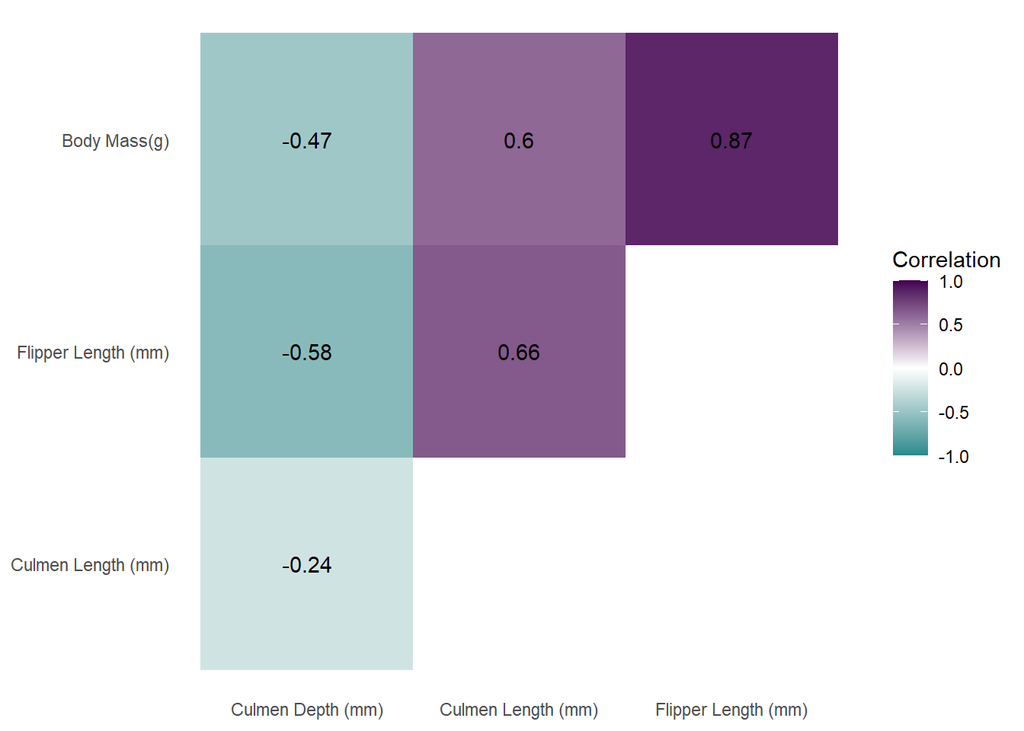

```r
ggplot(char_cor_long,
       aes(x = char2, y = char1, fill = cor)) +
  geom_tile() +
  geom_text(aes(label = nice_cor)) +
  scale_fill_gradient2(low = "#238A8DFF", mid = "white", high = "#440154FF",
                       limits = c(-1, 1),
                       name = "Correlation") +
  labs(x = NULL, y = NULL) +
  coord_equal() +
  theme_minimal() +
  theme(panel.grid = element_blank()) +
  scale_y_discrete(labels = c("body_mass_g" = "Body Mass(g)",
                              "flipper_length_mm" = "Flipper Length (mm)",
                              "culmen_length_mm" = "Culmen Length (mm)")) +
  scale_x_discrete(labels = c("culmen_depth_mm" = "Culmen Depth (mm)",
                              "flipper_length_mm" = "Flipper Length (mm)",
                              "culmen_length_mm" = "Culmen Length (mm)"))
```

We can also scale by points instead of tiles -

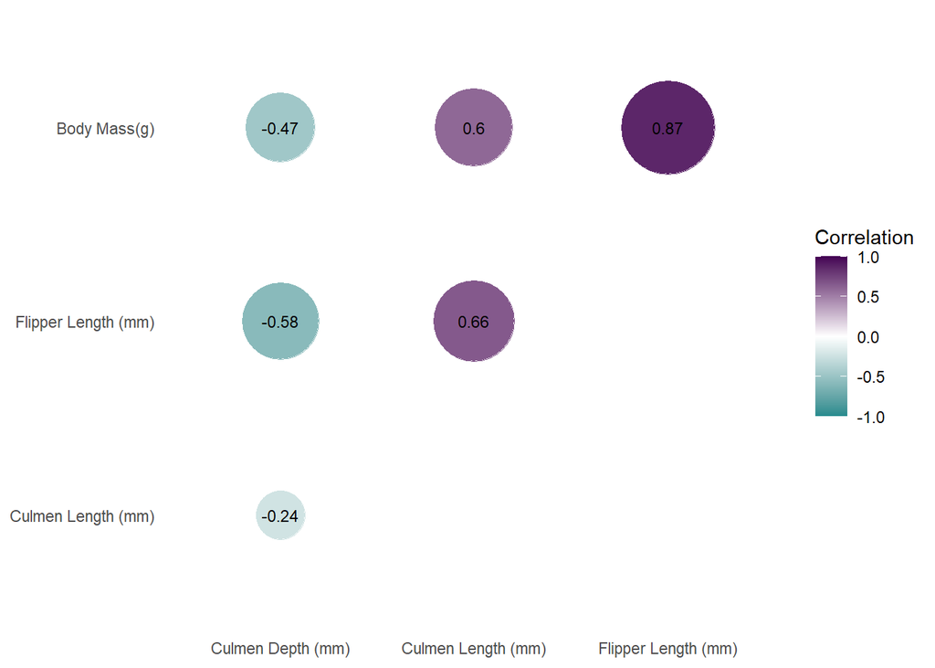

```r
ggplot(char_cor_long,
       aes(x = char2, y = char1, color = cor)) +
  geom_point(aes(size = abs(cor))) +
  geom_text(aes(label = nice_cor), color = "black", size = 3) +
  scale_color_gradient2(low = "#238A8DFF", mid = "white", high = "#440154FF",
                       limits = c(-1, 1),
                       name = "Correlation") +
  scale_size_area(max_size = 25, limits = c(-1, 1), guide = "none") +
  labs(x = NULL, y = NULL) +
  coord_equal() +
  theme_minimal() +
  theme(panel.grid = element_blank()) +
  scale_y_discrete(labels = c("body_mass_g" = "Body Mass(g)",
                              "flipper_length_mm" = "Flipper Length (mm)",
                              "culmen_length_mm" = "Culmen Length (mm)")) +
  scale_x_discrete(labels = c("culmen_depth_mm" = "Culmen Depth (mm)",
                              "flipper_length_mm" = "Flipper Length (mm)",
                              "culmen_length_mm" = "Culmen Length (mm)"))
```

### A much easier approach! ggcorrplot

Resource: http://www.sthda.com/english/wiki/ggcorrplot-visualization-of-a-correlation-matrix-using-ggplot2

```r
#install.packages("ggcorrplot")
```

```r
#remember need to load ggcorplot package for this code to work!

#work with the correlation matrix created earlier
char_correlations
```

```
                  culmen_depth_mm culmen_length_mm flipper_length_mm
culmen_depth_mm                 1       -0.2350529        -0.5838512
culmen_length_mm               NA        1.0000000         0.6561813
flipper_length_mm              NA               NA         1.0000000
body_mass_g                    NA               NA                NA
                  body_mass_g
culmen_depth_mm    -0.4719156
culmen_length_mm    0.5951098
flipper_length_mm   0.8712018
body_mass_g         1.0000000
```

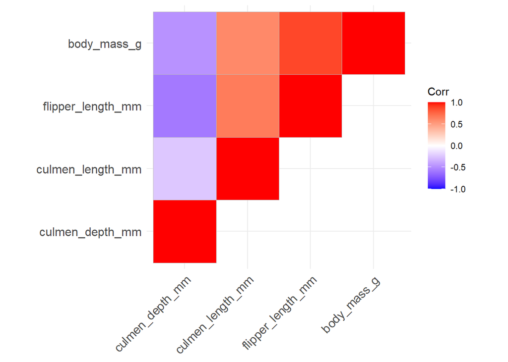

```r
ggcorrplot(char_correlations)
```

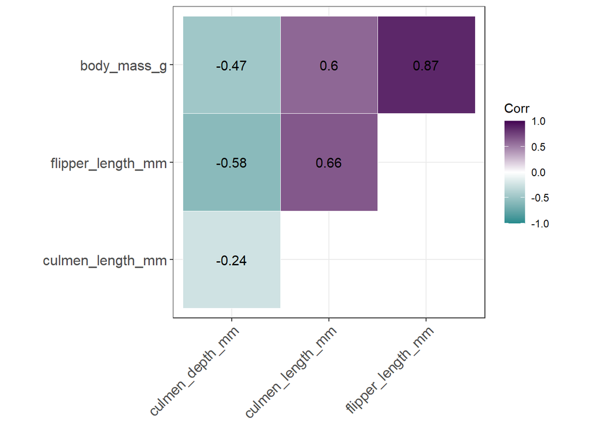

```r
#modify colors, etc
ggcorrplot(char_correlations,
           outline.col = "white",
           type="upper",
           lab=TRUE,
           ggtheme = theme_bw,
           colors = c("#238A8DFF", "white", "#440154FF"))
```

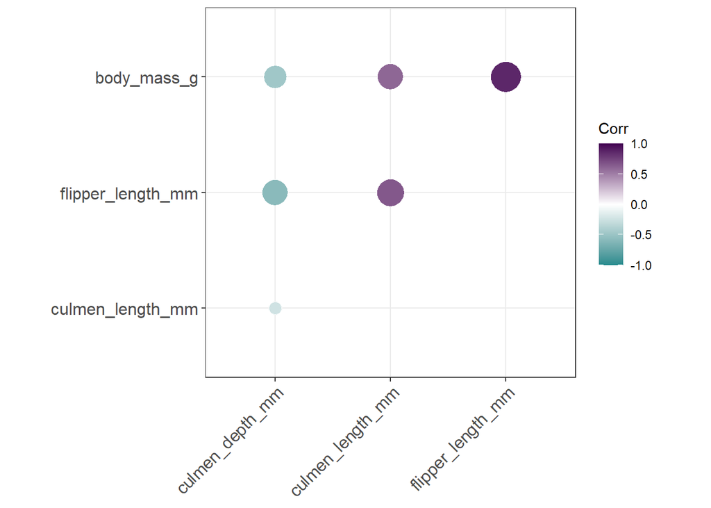

```r
#scaling by points
ggcorrplot(char_correlations,
           method = "circle",
           type="upper",
           outline.col = "white",
           ggtheme = theme_bw,
           colors = c("#238A8DFF", "white", "#440154FF"))
```

### Other Options - GGally

```r
#install.packages("GGally")
```

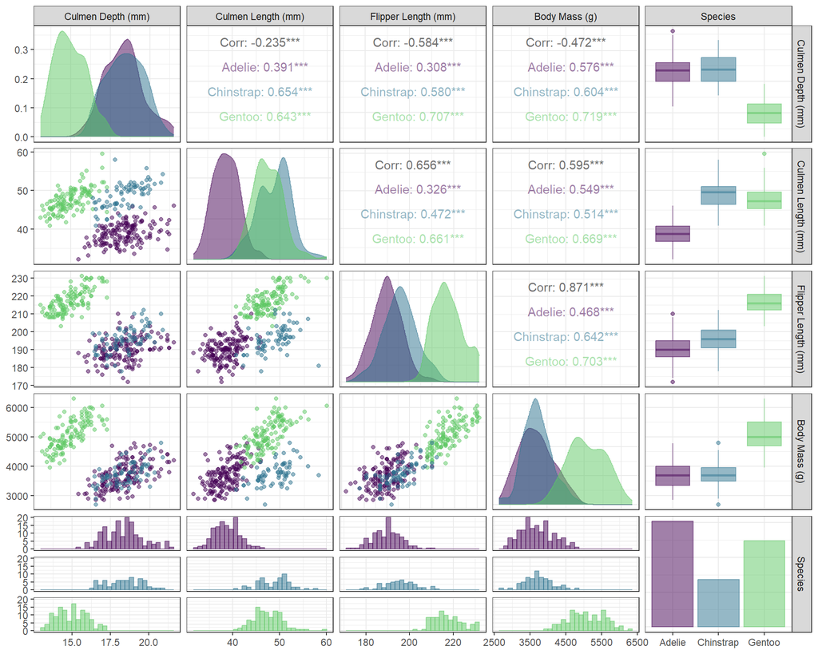

```r
#need library(GGally) for this code to work

ggpairs(data = pengs, aes(color = species, fill = species),
        columns = c('culmen_depth_mm', 'culmen_length_mm',
                    'flipper_length_mm', 'body_mass_g',
                    'species'),
        columnLabels = c("Culmen Depth (mm)", "Culmen Length (mm)",
                         "Flipper Length (mm)", "Body Mass (g)",
                         "Species")) +
  scale_color_viridis_d(alpha = 0.5, end = 0.75) +
  scale_fill_viridis_d(alpha = 0.5, end = 0.75) +
  theme_bw()
```

## Slope Graphs

Sometimes we want to show a comparison between two values that are paired or connected in some way.

We will use a slope graph to compare average weight between species - this isn’t necessarily recommended because we are not going to see a measure of the variability, but for illustration purposes we will make it work.

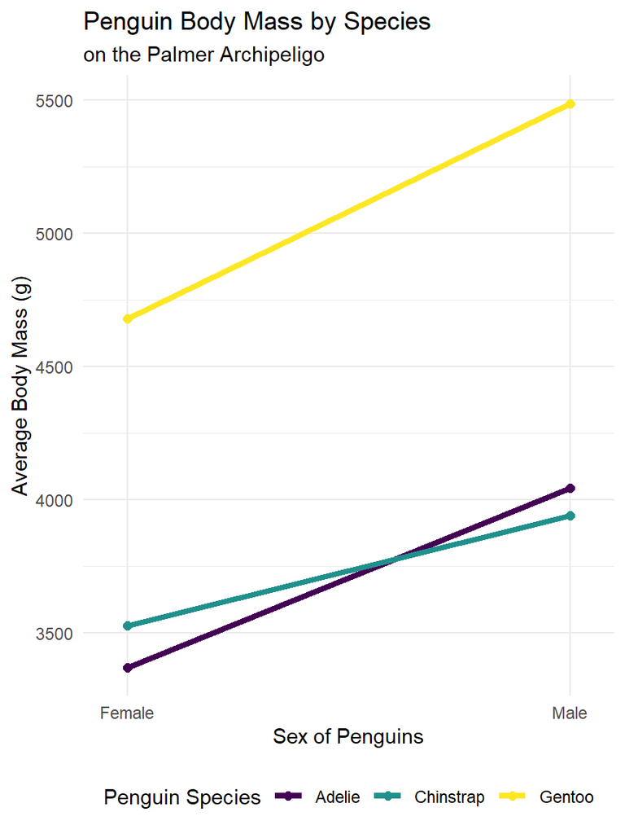

```r
pengs |>
  drop_na(sex) |>
  group_by(species, sex) |>
  summarise(`Average Body Mass (g)` = mean(body_mass_g, na.rm = TRUE)) |>
  ggplot(aes(x = sex, y = `Average Body Mass (g)`, group = species, color = species)) +
  geom_line(linewidth = 1.5) +
  geom_point(size = 2) +
  scale_colour_viridis_d() +
  scale_x_discrete(breaks = c("MALE","FEMALE"),
                   labels = c("Male", "Female")) +
  theme_minimal() +
  coord_cartesian(xlim = c(1.5, 1.5)) +
  labs(x = "Sex of Penguins",
       color = "Penguin Species",
       title = "Penguin Body Mass by Species",
       subtitle = "on the Palmer Archipeligo") +
  theme(legend.position = "bottom")
```

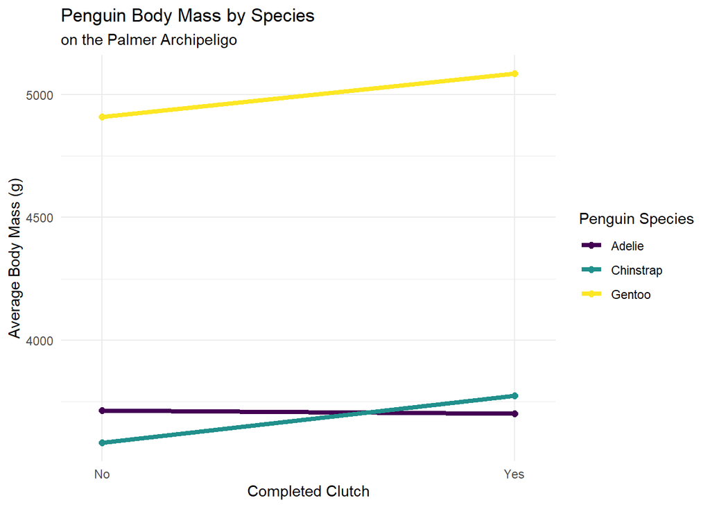

```r
pengs |>
  drop_na(clutch_completion) |>
  group_by(species, clutch_completion) |>
  summarise(`Average Body Mass (g)` = mean(body_mass_g, na.rm = TRUE)) |>
  ggplot(aes(x = clutch_completion, y = `Average Body Mass (g)`, group = species, color = species)) +
  geom_line(linewidth = 1.5) +
  geom_point(size = 2) +
  scale_colour_viridis_d() +
  theme_minimal() +
  coord_cartesian(xlim = c(1.5, 1.5)) +
  labs(x = "Completed Clutch",
       color = "Penguin Species",
       title = "Penguin Body Mass by Species",
       subtitle = "on the Palmer Archipeligo")
```